# Accessing online helminth data through R

tad

## The Problem

Data are everywhere, right? There are repositories like [Dryad](http://datadryad.org/), and more journals are implementing open-data policies. However, some databases don’t have a `download` button, and getting the data off the browser and into R can be a pain. However, these data may contribute to the development and testing of general ecological theory. For the longest time, I thought that the extraction of these online data would require another set of tools separate from `R`. This is not the case.

## The solution

Thankfully, there are some very smart people designing ways to use R to extract information from webpages. I will focus on [**rvest**](https://github.com/hadley/rvest), and how I used this package to ha**rvest** data on helminth parasites from the London Natural History Museum’s [helminth database](http://www.nhm.ac.uk/research-curation/scientific-resources/taxonomy-systematics/host-parasites/index.html).

The package is called `parasiteR`, and is currently hosted by the [ROpenSci folks](http://ropensci.org/). The package presently has 3 main functions, with a few more on the way. These core functions obtain host-parasite interaction data based on information on host (`findHost()`), parasite (`findParasite()`), or location (`findLocation()`).

I’ll start with an example. The code below finds all host parasite associations for *Gorilla gorilla*.

```r
#Install the package
#devtools::install_github('ropensci/parasiteR')

library(parasiteR)
gorillaParasites=findHost('Gorilla', 'gorilla')
head(gorillaParasites)
```

```
##                       Host               Parasite
## 1          Gorilla gorilla              Strongyle
## 2 Gorilla gorilla beringei              Strongyle
## 3          Gorilla gorilla          Strongyloidea
## 4          Gorilla gorilla     Trichostrongylidae
## 5          Gorilla gorilla Anoplocephala gorillae
## 6 Gorilla gorilla beringei Anoplocephala gorillae
##                           ParasiteFull
## 1                         (Strongyle)
## 2                         (Strongyle)
## 3                     (Strongyloidea)
## 4                (Trichostrongylidae)
## 5 Anoplocephala gorillae Nybelin, 1928
## 6 Anoplocephala gorillae Nybelin, 1928
```

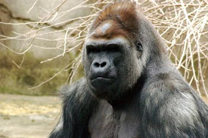

Now we have a list of parasites recorded on *G. gorilla*. How did we get there? Really easily.

First, we have to get the appropriate `url`. We do this by inserting the host genus and species into the appropriate spots on the `url`, and then pulling that html object into R.

```r
 hpUrl <- html(paste("http://www.nhm.ac.uk/research-curation/scientific-resources/taxonomy-systematics/host-parasites/database/results.jsp?dbfnsRowsPerPage=50000&x=13&y=5&paragroup=&fmsubgroup=Starts+with&subgroup=&fmparagenus=Starts+with&paragenus=&fmparaspecies=Starts+with&paraspecies=&fmhostgenus=Contains&hostgenus=", genus, "&fmhostspecies=Contains&hostspecies=", species, "&location=", location, "&hstate=&pstatus=&showparasites=on&showhosts=on&showrefs=on&groupby=parasite&search=Search", sep = ""))
```

Once we have the url, we need to extract the pertinent information. This is where the `rvest` package comes in handy, as we can extract the text (`html_text()`) under certain html tags (`.searchlink`).

```r
 names <- hpUrl %>%
                    html_nodes(".searchlink") %>%
                    html_text()
```

After a bit more formatting, we have a matrix of host-parasite associations. This is a simple application of `rvest`, and `parasiteR` uses only a tiny bit of the functionality of `rvest`. In the coming months, I plan to incorporate some data formatting and plotting functions, but the core functionality of the package is there.

Feel free to check out and contribute to parasiteR.